# Bayesian Multivariate Gaussian Mixtures with the Telescoping Sampler

Gertraud Malsiner-Walli, Sylvia Frühwirth-Schnatter, Bettina Grün

# Introduction

In this vignette we fit a Bayesian multivariate Gaussian mixture with a prior on the number of components $K$ to the thyroid data set available in the **mclust** package. We use the prior specification for model selection and the telescoping sampler to perform MCMC sampling as used in Frühwirth-Schnatter, Malsiner-Walli, and Grün (2021).

First, we load the package.

```r
library("telescope")
```

# The thyroid data set

We load the data set from package **mclust** and extract the variables for clustering omitting the variable indicating the known classification available in column named `"Diagnosis"`.

```r
data("thyroid", package = "mclust")
y <- as.matrix(thyroid[, 2:6])
z <- thyroid$Diagnosis
```

We extract the dimension of the data set and indicate the distribution of the known classification.

```r
r <- ncol(y)
N <- nrow(y)
table(z)
```

```
## z
##   Hypo Normal  Hyper
##     30    150     35
```

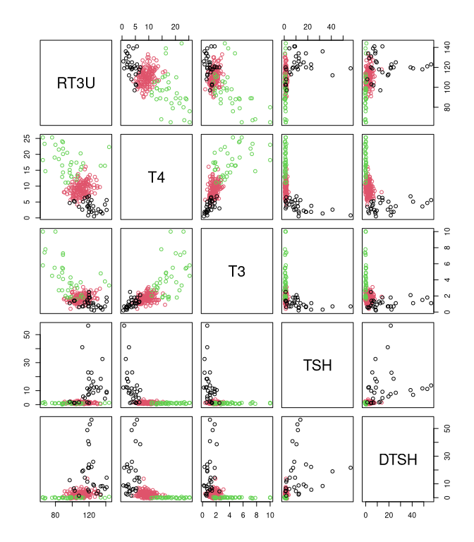

```r
pairs(y, col = z)
```

# Model specification

For multivariate observations $\mathbf{y}_1,\ldots,\mathbf{y}_N$ the following model with hierachical prior structure is assumed:

$$\begin{aligned}
\mathbf{y}_i \sim \sum_{k=1}^K \eta_k
f_N(\boldsymbol{\mu}_k,\boldsymbol{\Sigma_k})&\\
K \sim p(K)&\\
\boldsymbol{\eta} \sim Dir(e_0)& \qquad \text{with } e_0 \text{
fixed, } e_0\sim p(e_0) \text {, or } e_0=\frac{\alpha}{K}, \text{ with
} \alpha \text{ fixed or } \alpha \sim p(\alpha),\\
\boldsymbol{\mu}_k\sim N(\mathbf{b}_0,\mathbf{B}_0)\\
\boldsymbol{\Sigma} \sim \mathcal{W}^{-1}(c_0,\mathbf{C}_0)& \qquad
\text{with }E(\boldsymbol{\Sigma}) =\mathbf{C}_0/(c_0-(r+1)/2),\\
\mathbf{C}_0 \sim \mathcal{W}(g_0,\mathbf{G}_0)& \qquad \text{with
}E(\mathbf{C}_0) = g_0 \mathbf{G}_0^{-1}.
\end{aligned}$$

# Specification of the simulation and prior parameters

For MCMC sampling we need to specify `Mmax`, the maximum number of iterations, `thin`, the thinning imposed to reduce auto-correlation in the chain by only recording every `thin`ed observation, and `burnin`, the number of burn-in iterations not recorded.

```r
Mmax <- 5000
thin <- 10
burnin <- 100
```

The specifications of `Mmax` and `thin` imply `M`, the number of recorded observations.

```r
M <- Mmax/thin
```

For MCMC sampling, we need to specify `Kmax`, the maximum number of components possible during sampling, and `Kinit`, the initial number of filled components.

```r
Kmax <- 50
Kinit <- 10
```

We use a static specification for the weights with a gamma prior G(1, 20) on $e_0$.

```r
G <- "MixStatic"
priorOnE0 <- priorOnE0_spec("G_1_20", 1)
```

We need to select the prior on `K`. We use the prior $K-1 \sim BNB(1, 4, 3)$ as suggested in Frühwirth-Schnatter, Malsiner-Walli, and Grün (2021) for a model-based clustering context.

```r
priorOnK <- priorOnK_spec("BNB_143")
```

We select the hyperparameters for the priors on the component specific parameters as in Frühwirth-Schnatter, Malsiner-Walli, and Grün (2021).

```r
R <- apply(y, 2, function(x) diff(range(x)))
b0 <- apply(y, 2, median)
B_0 <- rep(1, r)
B0 <- diag((R^2) * B_0)
c0 <- 2.5 + (r-1)/2
g0 <- 0.5 + (r-1)/2
G0 <- 100 * g0/c0 * diag((1/R^2), nrow = r)
C0 <- g0 * chol2inv(chol(G0))
```

We use `kmeans()` with the specified initial number of filled components `Kinit` to determine an initial partition $S_0$ of the observations as well as initial values for the component-specific means $\mu_0$.

```r
set.seed(1234)
cl_y <- kmeans(y, centers = Kinit, nstart = 100, iter.max = 30)
S_0 <- cl_y$cluster
mu_0 <- t(cl_y$centers)
```

The component sizes are initially set to be equal and the component-specific variance-covariance matrices are diagonal matrices with half the value of `C0` in the diagonal.

```r
eta_0 <- rep(1/Kinit, Kinit)
Sigma_0 <- array(0, dim = c(r, r, Kinit))
Sigma_0[, , 1:Kinit] <- 0.5 * C0
```

# MCMC sampling

Using this prior specification as well as initialization and MCMC settings, we draw samples from the posterior using the telescoping sampler.

The first argument of the sampling function is the data followed by the initial partition and the initial parameter values for component-specific means, variances and sizes. The next set of arguments correspond to the hyperparameters of the prior setup (`c0`, `g0`, `G0`, `C0`, `b0`, `B0`). Then the setting for the MCMC sampling are specified using `M`, `burnin`, `thin` and `Kmax`. Finally the prior specification for the weights and the prior on the number of components are given (`G`, `priorOnK`, `priorOnE0`).

```r
estGibbs <- sampleMultNormMixture(
    y, S_0, mu_0, Sigma_0, eta_0,
    c0, g0, G0, C0, b0, B0,
    M, burnin, thin, Kmax,
    G, priorOnK, priorOnE0)
```

The sampling function returns a named list where the sampled parameters and latent variables are contained. The list includes the component means `Mu`, the weights `Eta`, the assignments `S`, the number of observations `Nk` assigned to components, the number of components `K`, the number of filled components `Kplus`, parameter values corresponding to the mode of the nonnormalized posterior `nonnormpost_mode`, the acceptance rate in the Metropolis-Hastings step when sampling $\alpha$ or $e_0$, $\alpha$ and $e_0$. These values can be extracted for post-processing.

```r
Mu <- estGibbs$Mu
Eta <- estGibbs$Eta
S <- estGibbs$S
Nk <- estGibbs$Nk
K <- estGibbs$K
Kplus <- estGibbs$Kplus
nonnormpost_mode <- estGibbs$nonnormpost_mode
acc <- estGibbs$acc
e0 <- estGibbs$e0
alpha <- estGibbs$alpha
```

# Convergence diagnostics of the run

We inspect the acceptance rate when sampling $e_0$ and the trace plot of the sampled $e_0$:

```r
sum(acc)/M
```

```
## [1] 0.366
```

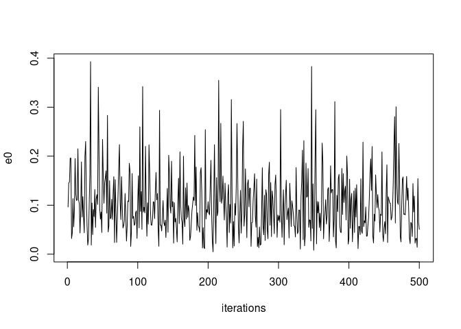

```r
plot(1:length(e0), e0,
     type = "l", ylim = c(0, max(e0)),
     xlab = "iterations", ylab = "e0")
```

We also inspect the distribution using a histogram as well as by determining some quantiles:

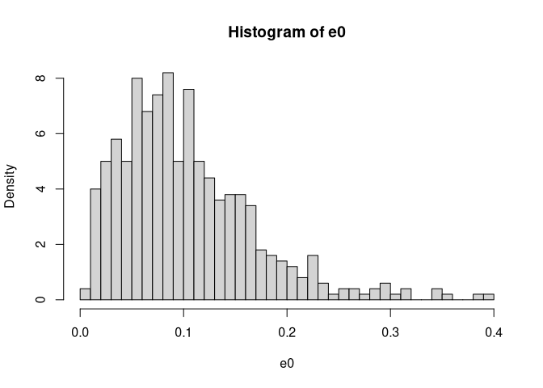

```r
hist(e0, freq = FALSE, breaks = 50)
```

```r
quantile(e0, probs = c(0.25, 0.5, 0.75))
```

```
##        25%        50%        75%
## 0.05673919 0.08883964 0.13463634
```

To further assess convergence, we also inspect the trace plots for the number of components $K$ and the number of filled components $K_+$.

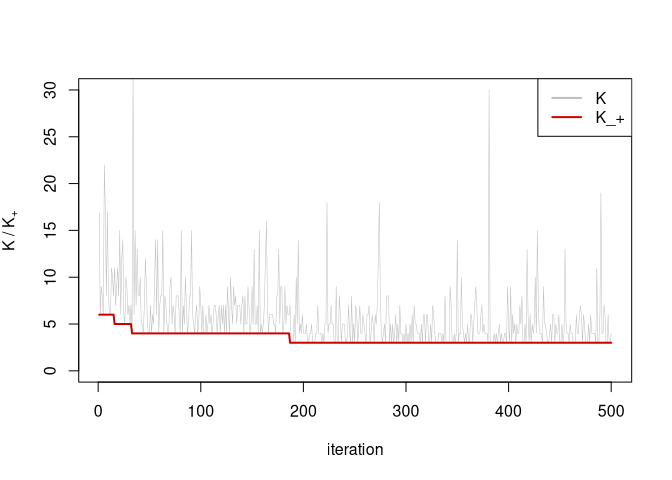

```r
plot(seq_along(K), K, type = "l", ylim = c(0, 30),
     xlab = "iteration", main = "",
     ylab = expression("K" ~ "/" ~ K["+"]),
     lwd = 0.5, col = "grey")
lines(seq_along(Kplus), Kplus, col = "red3", lwd = 2, lty = 1)
legend("topright", legend=c("K", "K_+"), col=c("grey", "red3"),lwd = 2)
```

# Identification of the mixture model

## Step 1: Estimating $K_+$ and $K$

We determine the posterior distribution of the number of filled components $K_+$, approximated using the telescoping sampler. We visualize the distribution using a barplot.

```r
Kplus <- rowSums(Nk != 0, na.rm = TRUE)
p_Kplus <- tabulate(Kplus, nbins = max(Kplus))/M
quantile(Kplus, probs = c(0.25, 0.5, 0.75))
```

```
## 25% 50% 75%
##   3   3   4
```

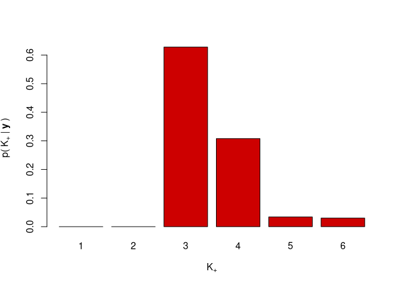

```r
barplot(p_Kplus/sum(p_Kplus), xlab = expression(K["+"]), names = 1:length(p_Kplus),
        col = "red3", ylab = expression("p(" ~ K["+"] ~ "|" ~ bold(y) ~ ")"))
```

The distribution is also characterized using the 1st and 3rd quartile as well as the median.

```r
quantile(Kplus, probs = c(0.25, 0.5, 0.75))
```

```
## 25% 50% 75%
##   3   3   4
```

We obtain a point estimate for $K_+$ by taking the mode and determine the number of MCMC draws where exactly $K_+$ components were filled.

```r
Kplus_hat <- which.max(p_Kplus)
Kplus_hat
```

```
## [1] 3
```

```r
M0 <- sum(Kplus == Kplus_hat)
M0
```

```
## [1] 314
```

We also determine the posterior distribution of the number of components $K$ directly drawn using the telescoping sampler.

```r
p_K <- tabulate(K, nbins = max(K))/M
quantile(K, probs = c(0.25, 0.5, 0.75))
```

```
## 25% 50% 75%
##   4   5   7
```

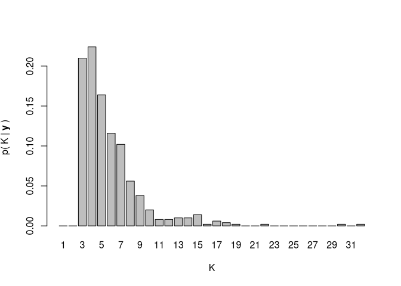

```r
barplot(p_K/sum(p_K), names = 1:length(p_K), xlab = "K",
        ylab = expression("p(" ~ K ~ "|" ~ bold(y) ~ ")"))
```

```r
which.max(tabulate(K, nbins = max(K)))
```

```
## [1] 4
```

## Step 2: Extracting the draws with exactly $\hat{K}_+$ non-empty components

First we select those draws where the number of non-empty groups was exactly $\hat{K}_+$:

```r
index <- Kplus == Kplus_hat
Nk[is.na(Nk)] <- 0
Nk_Kplus <- (Nk[index, ] > 0)
```

In the following we extract the cluster means, data cluster sizes and cluster assignments for the draws where exactly $\hat{K}_+$ components were filled.

```r
Mu_inter <- Mu[index, , , drop = FALSE]
Mu_Kplus <- array(0, dim = c(M0, r, Kplus_hat))
for (j in 1:r) {
  Mu_Kplus[, j, ] <- Mu_inter[, j, ][Nk_Kplus]
}

Eta_inter <- Eta[index, ]
Eta_Kplus <- matrix(Eta_inter[Nk_Kplus], ncol = Kplus_hat)
Eta_Kplus <- sweep(Eta_Kplus, 1, rowSums(Eta_Kplus), "/")

w <- which(index)
S_Kplus <- matrix(0, M0, N)
for (i in seq_along(w)) {
    m <- w[i]
    perm_S <- rep(0, Kmax)
    perm_S[Nk[m, ] != 0] <- 1:Kplus_hat
    S_Kplus[i, ] <- perm_S[S[m, ]]
}
```

## Step 3: Clustering and relabeling of the MCMC draws in the point process representation

For model identification, we cluster the draws of the means where exactly $\hat{K}_+$ components were filled in the point process representation using $k$-means clustering.

```r
Func_init <- t(nonnormpost_mode[[Kplus_hat]]$mu)
identified_Kplus <- identifyMixture(
    Mu_Kplus, Mu_Kplus, Eta_Kplus, S_Kplus, Func_init)
```

We inspect the non-permutation rate to assess how well separated the data clusters are and thus how easily one can obtain a suitable relabeling of the draws. Low values of the non-permutation rate, i.e., close to zero, indicate that the solution can be easily identified pointing to a good clustering solution being obtained.

```r
identified_Kplus$non_perm_rate
```

```
## [1] 0.006369427
```

## Step 4: Estimating data cluster specific parameters and determining the final partition

The relabeled draws are also returned which can be used to determine posterior mean values for data cluster specific parameters.

```r
colMeans(identified_Kplus$Mu)
```

```
##             [,1]      [,2]       [,3]
## [1,] 96.37492766 123.04691 110.331819
## [2,] 17.51362238   3.82414   9.071446
## [3,]  4.16036146   1.06573   1.720279
## [4,]  0.98658553  13.82446   1.305073
## [5,]  0.02358041  18.92051   2.499444
```

```r
colMeans(identified_Kplus$Eta)
```

```
## [1] 0.1701904 0.1308361 0.6989734
```

A final partition is also obtained based on the relabeled cluster assignments by assigning each observation to the cluster it has been assigned most often during sampling.

```r
z_sp <- apply(identified_Kplus$S, 2,
              function(x) which.max(tabulate(x, Kplus_hat)))
table(z_sp)
```

```
## z_sp
##   1   2   3
##  37  28 150
```

The final partition can also be compared to the known classification.

```r
table(z, z_sp)
```

```
##         z_sp
## z          1   2   3
##   Hypo     0  26   4
##   Normal   2   2 146
##   Hyper   35   0   0
```

```r
library("mclust")
classError(z_sp, z)$errorRate
```

```
## [1] 0.0372093
```

```r
adjustedRandIndex(z, z_sp)
```

```
## [1] 0.8779971
```

## Step 5: Visualizing the estimated classification

We include the information on the partition obtained in pairwise scatter plots of the varaibles used for clustering.

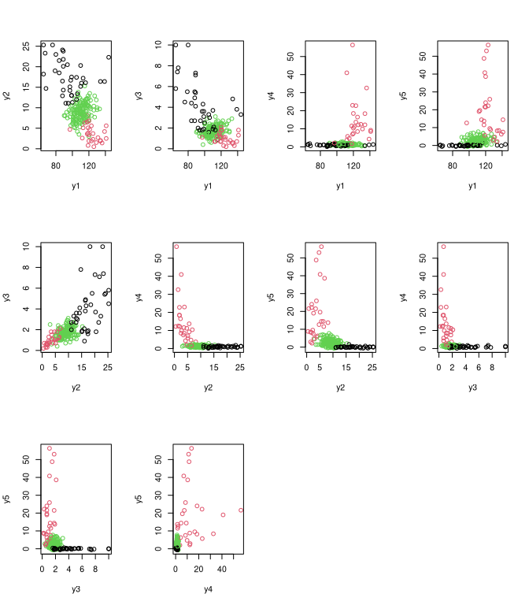

```r
plotScatter(y, z_sp, label = "y", trim = 0)
```

# References

Frühwirth-Schnatter, Sylvia, Gertraud Malsiner-Walli, and Bettina Grün. 2021. “Generalized Mixtures of Finite Mixtures and Telescoping Sampling.” *Bayesian Analysis* 16 (4): 1279–1307. https://doi.org/10.1214/21-BA1294.